# Prior Predictive Calibration for GP Magnitude (δ) and Length-scale (λ)

## 1 Goal

In my GP model, the nonlinear component is parameterized as

$$f \sim \mathcal{N}\!\left(0,\ \sigma^2 \delta^2 K_{\lambda}\right),
\qquad y = \mu + f + \varepsilon,\quad \varepsilon \sim \mathcal{N}(0,\sigma^2 I).$$

Thus the GP marginal s.d. is $\sigma_f=\sigma\delta$ and the noise s.d. is $\sigma_n=\sigma$, so

$$\frac{\sigma_f}{\sigma_n} = \delta.$$

This report uses **prior predictive calibration** to translate the qualitative statement “$\delta=1$ small, $\delta=2$ medium, $\delta=3$ large” into an operational statement about the typical amplitude of prior GP draws **over a finite domain** (with inputs scaled to $[0,1]$).

Key point: $\delta$ sets amplitude relative to noise, while $\lambda$ controls how that amplitude is expressed across $[0,1]$ (wiggly vs. smooth).

## 2 Setup

We assume:

- 1D grid $x \in [0,1]$ (can be generalized to multi-D later).
- Squared exponential kernel:
  $$k(x,x') = \exp\left(-\frac{(x-x')^2}{2\lambda^2}\right).$$
- We simulate functions from the prior and summarize:
  - `sd_over_sigma` $=\mathrm{sd}(f(x))/\sigma$
  - `range_over_sigma` $=(\max f - \min f)/\sigma$

These are interpretable as “in units of noise s.d.”.

## 3 Code

```r
library(MASS)
library(dplyr)
library(tidyr)
library(ggplot2)

# Squared-exponential kernel on 1D grid
k_se <- function(x, lambda) {
  D2 <- outer(x, x, "-")^2
  exp(- D2 / (2 * lambda^2))
}

# Draw f ~ N(0, sigma^2 * delta^2 * K_lambda)
draw_f_prior <- function(x, lambda, sigma = 1, delta = 1, jitter = 1e-10) {
  K <- k_se(x, lambda)
  K <- K + diag(jitter, nrow(K))
  Sigma_f <- (sigma^2) * (delta^2) * K
  as.numeric(mvrnorm(n = 1, mu = rep(0, length(x)), Sigma = Sigma_f))
}

summarize_effect <- function(f, sigma = 1) {
  c(
    sd_over_sigma    = sd(f) / sigma,
    range_over_sigma = diff(range(f)) / sigma
  )
}

calibrate_delta <- function(
  deltas = c(1, 2, 3),
  lambdas = c(0.1, 0.3, 0.7),
  n_grid = 200,
  n_draw = 2000,
  sigma = 1,
  seed = 1
) {
  set.seed(seed)
  x <- seq(0, 1, length.out = n_grid)

  out <- list()
  idx <- 1

  for (lambda in lambdas) {
    for (delta in deltas) {

      stats_mat <- matrix(NA_real_, nrow = n_draw, ncol = 2)
      colnames(stats_mat) <- c("sd_over_sigma", "range_over_sigma")

      for (b in 1:n_draw) {
        f <- draw_f_prior(x, lambda = lambda, sigma = sigma, delta = delta)
        stats_mat[b, ] <- summarize_effect(f, sigma = sigma)
      }

      qs <- apply(stats_mat, 2, quantile, probs = c(0.1, 0.5, 0.9))
      out[[idx]] <- data.frame(
        lambda = lambda,
        delta = delta,
        metric = colnames(stats_mat),
        q10 = qs[1, ],
        q50 = qs[2, ],
        q90 = qs[3, ],
        row.names = NULL
      )
      idx <- idx + 1
    }
  }
  bind_rows(out)
}

res <- calibrate_delta(
  deltas = c(1, 2, 3),
  lambdas = c(0.1, 0.3, 0.7),
  n_grid = 200,
  n_draw = 2000,
  sigma = 1,
  seed = 123
)
```

## 4 Results

### 4.1 Full table

```r
res %>%
  mutate(lambda = signif(lambda, 3)) %>%
  arrange(lambda, delta, metric)
```

```
   lambda delta           metric       q10       q50        q90
1     0.1     1 range_over_sigma 1.9246239 2.9334732  4.1088411
2     0.1     1    sd_over_sigma 0.5330453 0.8197869  1.1883823
3     0.1     2 range_over_sigma 3.9138272 5.7804467  8.2854269
4     0.1     2    sd_over_sigma 1.0511155 1.6236939  2.3936203
5     0.1     3 range_over_sigma 5.9313889 8.7970507 12.4266733
6     0.1     3    sd_over_sigma 1.6093772 2.4649478  3.5485796
7     0.3     1 range_over_sigma 0.8455330 1.7000249  2.9288325
8     0.3     1    sd_over_sigma 0.2446817 0.5353827  0.9626802
9     0.3     2 range_over_sigma 1.6610467 3.3935943  5.7900923
10    0.3     2    sd_over_sigma 0.4876756 1.0738231  1.9787584
11    0.3     3 range_over_sigma 2.4549661 5.0923274  8.8909214
12    0.3     3    sd_over_sigma 0.7208248 1.6130544  3.0470741
13    0.7     1 range_over_sigma 0.3483521 0.8931842  1.8495088
14    0.7     1    sd_over_sigma 0.1008785 0.2750885  0.5862687
15    0.7     2 range_over_sigma 0.6850282 1.8795910  3.8214355
16    0.7     2    sd_over_sigma 0.2020926 0.5761469  1.2253029
17    0.7     3 range_over_sigma 1.0025491 2.6403650  5.6157632
18    0.7     3    sd_over_sigma 0.3004151 0.8027990  1.8053226
```

### 4.2 Visualize: median range (in noise s.d.) as a function of $\lambda$

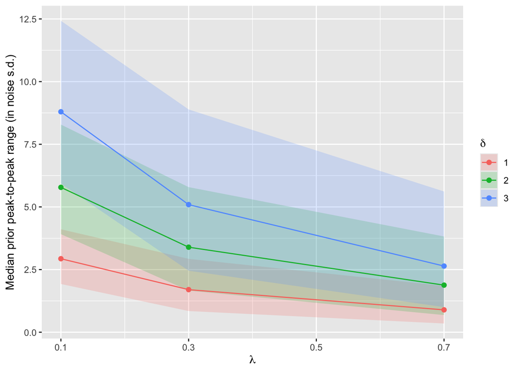

```r
plot_df <- res %>%
    filter(metric == "range_over_sigma") %>%
    mutate(lambda = as.numeric(lambda))

ggplot(plot_df, aes(x = lambda, y = q50, group = factor(delta), color = factor(delta))) +
    geom_ribbon(aes(ymin = q10, ymax = q90, fill = factor(delta)), alpha = 0.2, color = NA) +
    geom_line() +
    geom_point(size = 1.8) +
    scale_x_continuous(breaks = c(0.1, 0.3, 0.5, 0.7)) +
    labs(
        x = expression(lambda),
        y = "Median prior peak-to-peak range (in noise s.d.)",
        linetype = expression(delta),
        fill = expression(delta),
        color = expression(delta)
    )
```

- For fixed $\delta$, increasing $\lambda$ makes the GP smoother over ([0,1]), so the observed range over the finite domain drops.
- For fixed $\lambda$, increasing $\delta$ scales amplitude roughly linearly.

### 4.3 One illustrative set of draws

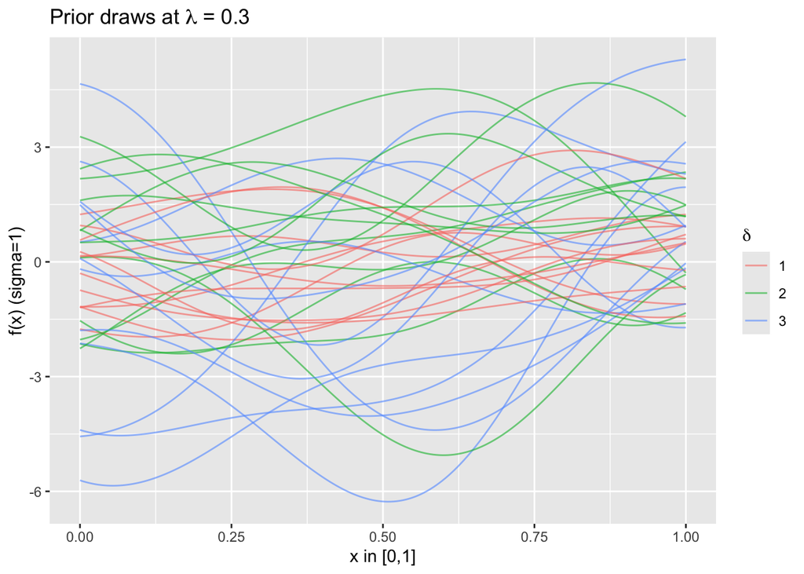

```r
set.seed(1)
x <- seq(0, 1, length.out = 200)

lambda_show <- 0.3
deltas_show <- c(1,2,3)
n_show <- 12

draws <- lapply(deltas_show, function(d){
  replicate(n_show, draw_f_prior(x, lambda_show, sigma = 1, delta = d), simplify = FALSE)
})

df_draws <- bind_rows(lapply(seq_along(deltas_show), function(i){
  d <- deltas_show[i]
  mats <- draws[[i]]
  bind_rows(lapply(seq_along(mats), function(j){
    data.frame(x = x, f = mats[[j]], delta = d, draw = j)
  }))
}))

ggplot(df_draws, aes(x = x, y = f, group = interaction(delta, draw), color = factor(delta))) +
    geom_line(alpha = 0.6, linewidth = 0.5) +
    labs(
        x = "x in [0,1]",
        y = "f(x) (sigma=1)",
        color = expression(delta),
        title = expression(paste("Prior draws at ", lambda, " = 0.3"))
    )
```

## 5 Discussion

1. $\delta$ is scale-free in $y$. Since $\frac{\sigma_f}{\sigma_n} = \delta$, not scaling $y$ does not hinder interpretation of $\delta$.
2. Small/medium/large depends on $\lambda$ regime. The calibration becomes concrete once we pick a reference $\lambda$ (e.g. $\lambda = 1/3$ in simulations).
3. Proposed paper sentence (draft):  
   “With inputs scaled to $[0,1]$ and moderate smoothness ($\lambda = 0.3$), prior GP draws have median peak-to-peak ranges of approximately $(r_1, r_2, r_3)$ noise standard deviations for $\delta = 1, 2, 3$, respectively; we therefore treat $\delta \approx 1, 2, 3$ as small/medium/large nonlinear magnitudes under this standardization.”
4. Next step (if needed): repeat the same calibration but integrate over the $\lambda$ prior (instead of conditioning on a grid of $\lambda$ values), so the calibration matches the actual prior used in the model.

## 6 Optional extension: integrate over a λ prior (marginal calibration)

If we have a prior for λ, we can sample λ from that prior and repeat the same summaries to get an unconditional calibration.

```r
r_lambda <- function(n) 1 / rgamma(n, shape = 3, rate = 0.8)

calibrate_delta_marginal_lambda <- function(
  deltas = c(1,2,3),
  n_grid = 200,
  n_draw = 2000,
  sigma = 1,
  seed = 1
) {
  set.seed(seed)
  x <- seq(0, 1, length.out = n_grid)

  out <- list()
  idx <- 1

  for (delta in deltas) {
    stats_mat <- matrix(NA_real_, nrow = n_draw, ncol = 2)
    colnames(stats_mat) <- c("sd_over_sigma", "range_over_sigma")

    lambdas <- r_lambda(n_draw)

    for (b in 1:n_draw) {
      f <- draw_f_prior(x, lambda = lambdas[b], sigma = sigma, delta = delta)
      stats_mat[b, ] <- summarize_effect(f, sigma = sigma)
    }

    qs <- apply(stats_mat, 2, quantile, probs = c(0.1, 0.5, 0.9))
    out[[idx]] <- data.frame(
      delta = delta,
      metric = colnames(stats_mat),
      q10 = qs[1, ],
      q50 = qs[2, ],
      q90 = qs[3, ],
      row.names = NULL
    )
    idx <- idx + 1
  }

  bind_rows(out)
}

res_marg <- calibrate_delta_marginal_lambda(deltas = c(1,2,3), n_draw = 2000, seed = 123)
res_marg
```

```
  delta           metric       q10       q50      q90
1     1    sd_over_sigma 0.1710754 0.5197724 1.014194
2     1 range_over_sigma 0.5768022 1.6770188 3.099324
3     2    sd_over_sigma 0.3470099 1.0007375 1.966742
4     2 range_over_sigma 1.1554434 3.2738449 6.117851
5     3    sd_over_sigma 0.5251997 1.6084901 3.085172
6     3 range_over_sigma 1.7606650 5.1968917 9.625503
```